# Data Science Final Project

Yael Yossefy

2025-12-11

# Load in Libraries and Data

```r
library(dplyr)
library(e1071)
library(tidyr)
library(lubridate)
library(sqldf)
library(tree)
```

```r
vitals <- read.csv('lab and vitals.csv')
baselines <- read.csv('baselines.csv')
```

# Clean Data

To pre-process the vitals and lab results data before analysis, I converted the time_stamp to a POSIXct class and renamed the names of the vitals and labs. The vitals dataset now includes the following variables: subject (the patient id), name (the name of the lab/vital results), value (the numeric value of the result), and time_stamp (the time that the lab/vital was collected). As for the names of the labs included, we have: sbp (systolic blood pressure), dbp (diastolic blood pressure), hr (heart rate - beats per minute), resp_rate (respiratory rate - breaths per minute), and spo2 (oxygen levels). Finally, we removed any rows with NAs, or missing values.

```r
vitals_clean <- vitals %>%
  mutate(
    time_stamp = ymd_hms(time_stamp),
    name = case_when(
      name == "vs_bp_noninvasive (s)" ~ "sbp",
      name == "s_bp_noninvasive (d)"  ~ "dbp",
      name == "vs_hr_hr"              ~ "hr",
      name == "xp_resp_rate_pt"       ~ "resp_rate",
      name == "xp_resp_spo2"          ~ "spo2",
      TRUE ~ name
    )
  ) %>%
  drop_na()
```

# Feature Engineering

## Distributional Summary Metrics

```r
vitals_stats <- vitals_clean %>%
  group_by(subject, name) %>%
  summarise(
    mean = mean(value),
    sd   = sd(value),
    iqr = IQR(value),
    skewness   = skewness(value, type = 2),
    .groups    = "drop"
  )


vitals_stats_wide <- vitals_stats %>%
  pivot_wider(
    id_cols = subject,
    names_from = name,
    values_from = c(mean, sd, iqr, skewness),
    names_glue = "{.value}_{name}"
  )
```

```r
baseline_vitals_stats_joined <- sqldf("
  SELECT
    b.*,
    v.*
  FROM baselines b
  LEFT JOIN vitals_stats_wide v
    ON b.mrn = v.subject
")
```

## Temporal Dynamics

```r
library(slider)

temporal <- vitals_clean %>%
    arrange(subject, name, time_stamp) %>%
    group_by(subject, name) %>%
    mutate(
      time_num = as.numeric(time_stamp),  # seconds since epoch
      roll_sd  = slide_dbl(
        value,
        sd,
        .before = 3 - 1,
        .complete = TRUE
      )
    ) %>%
    summarise(
      # Direction of change / trend
      slope = if (n() >= 2)
        coef(lm(value ~ time_num))[2]
      else NA_real_,

      # Net shift
      net_shift = last(value) - first(value),

      # Volatility
      vol_mean = mean(roll_sd, na.rm = TRUE),

      # Optional extras (often useful)

      first_value = first(value),
      last_value  = last(value),

      .groups = "drop"
    )
```

```r
temporal_wide <- temporal %>%
  pivot_wider(
    id_cols = subject,
    names_from = name,
    values_from = c(slope, net_shift, vol_mean),
    names_glue = "{.value}_{name}"
  )
```

```r
temporal_joined <- sqldf("
  SELECT
    s.*,
    t.*
  FROM baseline_vitals_stats_joined s
  LEFT JOIN temporal_wide t
    ON s.subject = t.subject
")
```

## Clinically Anchored Metrics

Blood Pressure Category Systolic and Diastolic Pressure (mm Hg) Normal Less than 120 systolic pressure AND Less than 80 diastolic pressure Elevated 120 to 129 systolic pressure AND Less than 80 diastolic pressure High Blood Pressure Stage 1 130 to 139 systolic pressure OR 80 to 89 diastolic pressure High Blood Pressure Stage 2 140 or higher systolic pressure OR 90 or higher diastolic pressure Hypertensive Crisis Higher than 180 systolic pressure OR Higher than 120 diastolic pressure Contact your provider immediately.

A normal heart rate (at rest) is 60 to 100 beats per minute. (https://my.clevelandclinic.org/health/diseases/16749-arrhythmia)

The normal respiratory rate for an adult at rest is from 12 to 20 breaths per minute. A respiratory rate under 12 or over 25 breaths per minute is cause for concern. (https://www.lung.org/blog/respiratory-rate-vital-signs).

```r
library(tibble)

thresholds_tbl <- tibble(
  vital = c(
    "sbp", "sbp", "sbp", "sbp", "sbp",   # systolic
    "dbp", "dbp", "dbp", "dbp",    # diastolic
    "spo2", "spo2",
    "resp_rate", "resp_rate", "resp_rate",
    "hr", "hr", "hr"



  ),
  category = c(
    "Normal", "Elevated", "Stage 1 Hypertension", "Stage 2 Hypertension", "Severe/Hypertensive Emergency",
    "Normal", "Stage 1 Hypertension", "Stage 2 Hypertension", "Severe/Hypertensive Emergency",
    "Low", "Normal",
    "Low", "Normal", "High",
    "Low", "Normal", "High"
  ),
  low  = c(
    -Inf, 120, 129.5, 139.5, 180,   # systolic lower bounds
    -Inf, 80, 90, 120,     # diastolic lower bounds
    -Inf, 95,
    -Inf, 12, 20,
    -Inf, 60, 100
  ),
  high = c(
    119.999, 129.5, 139.5, 179.99999, Inf,  # systolic upper bounds
    79.999, 89.999, 119.999, Inf,      # diastolic upper bounds
    95, Inf,
    12, 20, Inf,
    60, 100, Inf
  )
)
```

```r
library(sqldf)

vitals_labeled <- sqldf("
  SELECT
    v.subject,
    v.time_stamp,
    v.name,
    v.value,
    t.category,
    t.low,
    t.high
  FROM vitals_clean v
  LEFT JOIN thresholds_tbl t
    ON v.name = t.vital
   AND v.value > t.low
   AND v.value < t.high
")
```

```r
library(dplyr)

category_counts <- vitals_labeled %>%
  count(name, category) %>%
  arrange(name, desc(n))

category_counts
```

```
##         name             category      n
## 1        dbp               Normal 124220
## 2         hr               Normal 126444
## 3  resp_rate                 High 124272
## 4  resp_rate               Normal      1
## 5        sbp Stage 1 Hypertension  71521
## 6        sbp             Elevated  52501
## 7        sbp Stage 2 Hypertension      3
## 8        sbp               Normal      2
## 9       spo2                  Low 103544
## 10      spo2               Normal  19783
```

```r
vitals_abn <- vitals_labeled %>%
  mutate(is_abn = category != 'Normal')
```

```r
vitals_abn_wide <-  vitals_abn %>%
  group_by(subject, name) %>%
  summarise(
    abn_count = sum(is_abn),
    abn_prop  = mean(is_abn)
 ) %>%
  ungroup() %>%
  pivot_wider(
    id_cols = subject,
    names_from = name,
    values_from = c(abn_count, abn_prop),
    names_glue = "{.value}_{name}"
  )
library(dplyr)


temporal_joined <- temporal_joined %>%
  dplyr::select(-subject)


vitals_joined <- sqldf("
  SELECT
    t.*,
    a.abn_prop_spo2
  FROM temporal_joined t
  LEFT JOIN vitals_abn_wide a
    ON t.mrn = a.subject
")
```

# Prepare data for Modeling

```r
full_data <- vitals_joined %>%
  dplyr::select(-c("mrn")) %>%
  mutate(across(c(sex.factor, hypoxia_ed.factor, smoke_vape, htn.factor, pulm___1.factor, renal___1.factor, renal___2.factor, cad.factor, cancer, any_immunosuppression, symptoms___1.factor, symptoms___2.factor, symptoms___10.factor, symptoms___9.factor, symptoms___8.factor, symptoms___3.factor, first_cxr_results___0.factor, first_cxr_results___1.factor, first_cxr_results___2.factor, first_cxr_results___3.factor, Ed_before_order_set, event), as.factor))

full_data <- full_data %>%
  mutate(
    event = as.factor(event),
    across(where(is.logical), as.factor),
    across(where(is.character), as.factor)
  )
```

```r
# Create a 70/30 train/test split by sampling row indices for the training set
train_idx <- sample(1:nrow(full_data), size = 0.7*nrow(full_data), replace = FALSE)

train_data <- full_data[train_idx,]
test_data <- full_data[-train_idx,]
```

# Models

## Logistic Regression

```r
logistic.out <- glm(event ~ ., family = binomial, data = train_data)
pred.class <- predict(logistic.out, newdata = test_data, type = "response")
pred.class <- ifelse(pred.class>0.5,"Yes","No")
mean(pred.class != test_data$event)
```

```
## [1] 0.2079208
```

```r
library('MASS')
QDA.error <- function(Train, Test){
  qda.out <- qda(event ~ .,data=Train)
  pred.class = predict(qda.out,Test)$event
  mean(pred.class != Test$event)
}

##Get misclassification error rate in validation data
QDA.error(train_data, test_data)
```

```
## [1] NaN
```

```r
train_data <- train_data %>%
  relocate(event, .after = last_col())

test_data <- test_data %>%
  relocate(event, .after = last_col())
```

```r
PickBest <- function(X, p) {
  # Convert event factor ("No"/"Yes") to numeric 0/1
  y <- as.numeric(X$event == "Yes")

  # Compute correlations
  correlations <- numeric(p)
  for (i in 26:p) {
    correlations[i] <- cor(X[, i], y, use = "complete.obs")
  }

  # Sort variables by absolute correlation (better for selection)
  sorted <- data.frame(
    Variable = names(X)[1:p],
    Cor = correlations
  ) %>%
    dplyr::arrange(desc(abs(Cor)))

  # Return top 20 variable names
  sorted$Variable[1:20]
}
```

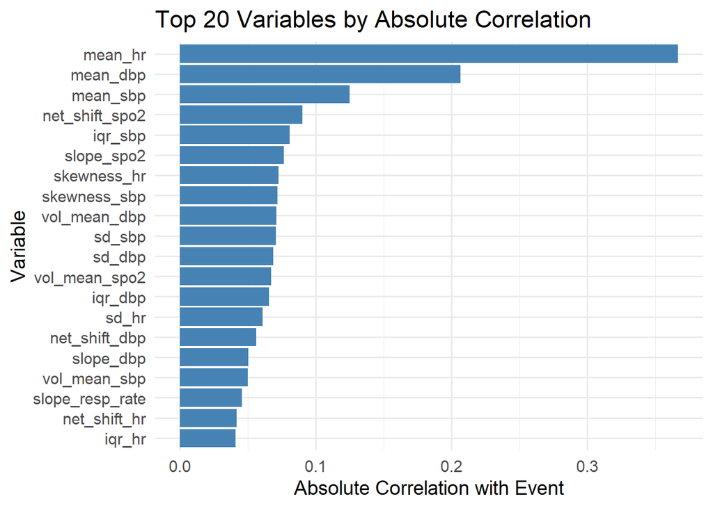

```r
best20 <- PickBest(train_data, p=61)

library(ggplot2)
library(dplyr)

# Compute correlations for the top 20 variables
y <- as.numeric(train_data$event == "Yes")

cor_data <- data.frame(
  Variable = best20,
  Correlation = sapply(best20, function(var) cor(train_data[[var]], y, use = "complete.obs"))
)

# Take absolute correlations for plotting
cor_data <- cor_data %>%
  mutate(AbsCorrelation = abs(Correlation)) %>%
  arrange(AbsCorrelation)

# Bar plot
ggplot(cor_data, aes(x = reorder(Variable, AbsCorrelation), y = AbsCorrelation)) +
  geom_bar(stat = "identity", fill = "steelblue") +
  coord_flip() +  # Horizontal bars
  labs(title = "Top 20 Variables by Absolute Correlation",
       x = "Variable",
       y = "Absolute Correlation with Event") +
  theme_minimal(base_size = 14)
```

```r
# Get the first 25 predictor columns (excluding event)
first25 <- colnames(train_data)[1:25]
first25 <- setdiff(first25, "event")   # safety: remove event if present

# Combine first 25 predictors + best20 predictors
all_predictors <- union(first25, best20)

# Build formula
formula_glm <- as.formula(
  paste("event ~", paste(all_predictors, collapse = " + "))
)


model <- glm(formula_glm, data = train_data, family = binomial)


probs <- predict(model, newdata = test_data, type = "response")
pred_class <- ifelse(probs > 0.5, "Yes", "No")

misclass_error <- mean(pred_class != test_data$event)
misclass_error
```

```
## [1] 0.200495
```

## Classification Tree

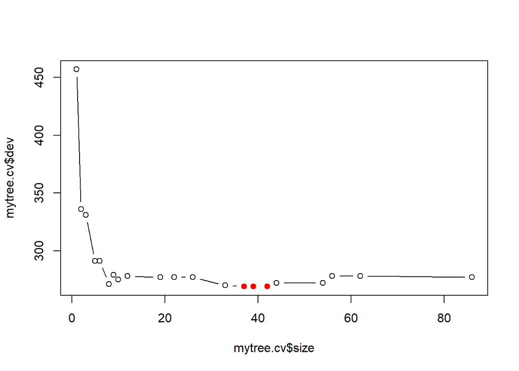

```r
# Fit a classification tree on the training set using Gini impurity
mytree <- tree(event ~ ., data = train_data, split = "gini")

# Run 10-fold cross-validation on the training tree using misclassification pruning
mytree.cv <- cv.tree(mytree, FUN=prune.misclass, K=10)

# Plot cross-validated deviance (error) as a function of tree size
plot(mytree.cv$size, mytree.cv$dev, type = "b")
# Highlight the size(s) that achieve the minimum CV deviance in red
points(
  x = mytree.cv$size[mytree.cv$dev == min(mytree.cv$dev)],
  y = rep(min(mytree.cv$dev), sum(mytree.cv$dev == min(mytree.cv$dev))),
  col = "red", pch = 19
)
```

```r
# Prune the original tree to the optimal size determined from cross-validation
final.tree = prune.tree(mytree, best = mytree.cv$size[mytree.cv$dev == min(mytree.cv$dev)])
```

[figure not shown]

```r
# TODO: Visualize the pruned (final) tree with split points and predicted class labels
plot(final.tree); text(final.tree, pretty = 0)
```

```r
# Generate class predictions on the test set using the pruned tree
mypredict=predict(final.tree, newdata=test_data, type="class")

# Create a confusion matrix comparing predicted vs. actual classes
tmp=table(Predicted = mypredict, Actual = test_data$event)
tmp
```

```
##          Actual
## Predicted  No Yes
##       No  142  44
##       Yes  74 144
```

```r
misclass_rate = 1 - sum(diag(tmp)) / sum(tmp)
misclass_rate
```

```
## [1] 0.2920792
```

```r
library(randomForest)
library(gbm)
rf_bag <- randomForest(event~.-event,data=train_data,mtry=max(floor(sqrt(61)),1),ntree=500, importance = TRUE)


# TODO: Inspect importance table for the RF model
importance(rf_bag)
```

```
##                                        No         Yes MeanDecreaseAccuracy
## Age                          21.819627649 18.54365522         25.654314557
## sex.factor                   -0.077177241  1.98594475          1.338130021
## bmi                          13.956086054 14.37176621         19.406495630
## hypoxia_ed.factor            -0.266038922  0.34388588          0.028231158
## smoke_vape                   -0.873730153 -2.93677855         -2.784217207
## dm.factor                     0.966065519 -0.09296319          0.706033545
## htn.factor                    1.699936882 -1.59112652          0.144208922
## pulm___1.factor               1.216685378 -0.46051021          0.441197511
## renal___1.factor             -0.919811464 -1.80186690         -1.853023927
## renal___2.factor             -1.110744450  0.01050054         -1.114048959
## cad.factor                   -0.378858759 -1.84643449         -1.539056840
## cancer                        2.018521790  5.25284241          5.249131872
## any_immunosuppression         1.559159277  0.26336744          1.400053286
## symptoms___1.factor          -0.074102016  1.01150969          0.707901945
## symptoms___2.factor          -0.158089819  0.03434519         -0.083554982
## symptoms___10.factor          0.360752683 -0.44841907         -0.053265654
## symptoms___9.factor          -0.318723612 -0.11581403         -0.273283432
## symptoms___8.factor          -0.249579228 -0.33751255         -0.474078219
## symptoms___3.factor          -0.763169908  1.15785000          0.222865841
## first_cxr_results___0.factor  1.047381819  1.63885294          1.726356837
## first_cxr_results___1.factor  0.205593960  1.08600482          0.812344136
## first_cxr_results___2.factor  2.465596434 -0.35767254          1.639928943
## first_cxr_results___3.factor  1.353629835 -1.10793063          0.244595744
## duration_symptoms             1.838902504  2.02395123          2.720771698
## Ed_before_order_set          -0.023325328  1.33941729          1.024401142
## mean_dbp                      7.758060808  7.80317758         10.789256127
## mean_hr                      23.600224567 22.65633192         28.985573542
## mean_resp_rate               -0.671608153  0.13959967         -0.342085233
## mean_sbp                      1.949725776  4.50630977          4.384424117
## mean_spo2                     0.500435990 -0.28667525          0.159779358
## sd_dbp                        1.933325934 -1.14878560          0.620318064
## sd_hr                         1.222487441 -0.11700318          0.807581832
## sd_resp_rate                 -0.710616447  2.72124126          1.249242292
## sd_sbp                        0.912818708  1.28146964          1.602368482
## sd_spo2                      -0.597852614  0.90199828          0.316938425
## iqr_dbp                       1.161609665  1.60654064          2.082682298
## iqr_hr                       -1.897207933 -0.89041054         -1.989683917
## iqr_resp_rate                -0.330945470 -0.74892484         -0.732687427
## iqr_sbp                       0.462512891  3.98960472          3.205925231
```

[output cut: 69 more lines]

```
## slope_hr                            7.6511169
## slope_resp_rate                     8.6006177
## slope_sbp                           8.3843485
## slope_spo2                          9.2787608
## net_shift_dbp                       9.5956876
## net_shift_hr                        8.7390859
## net_shift_resp_rate                 7.9648794
## net_shift_sbp                       8.1736217
## net_shift_spo2                     10.5603790
## vol_mean_dbp                        9.1022341
## vol_mean_hr                         7.7030214
## vol_mean_resp_rate                  8.0999496
## vol_mean_sbp                        8.6304646
## vol_mean_spo2                       9.8505526
## abn_prop_spo2                       8.1032899
```

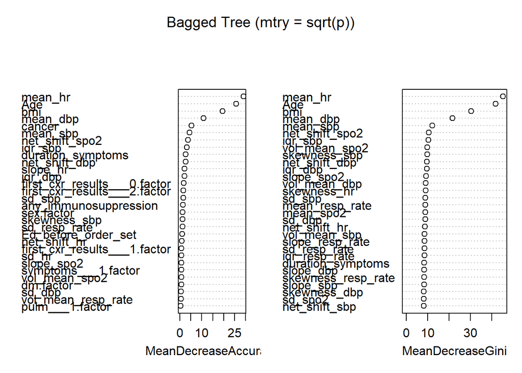

```r
# Plot variable importance for bagged model
varImpPlot(rf_bag, main = "Bagged Tree (mtry = sqrt(p))")
```

```r
# 5) Evaluate on the Test Set
# ----------------------------
# TODO: Generate class predictions on the held-out test set
pred_bag <- predict(rf_bag, newdata = test_data, type = 'class')

# TODO: Compute accuracy for each model
misclass_bag <- mean(pred_bag != test_data$event)

# TODO: Print accuracies
print(misclass_bag)
```

```
## [1] 0.210396
```

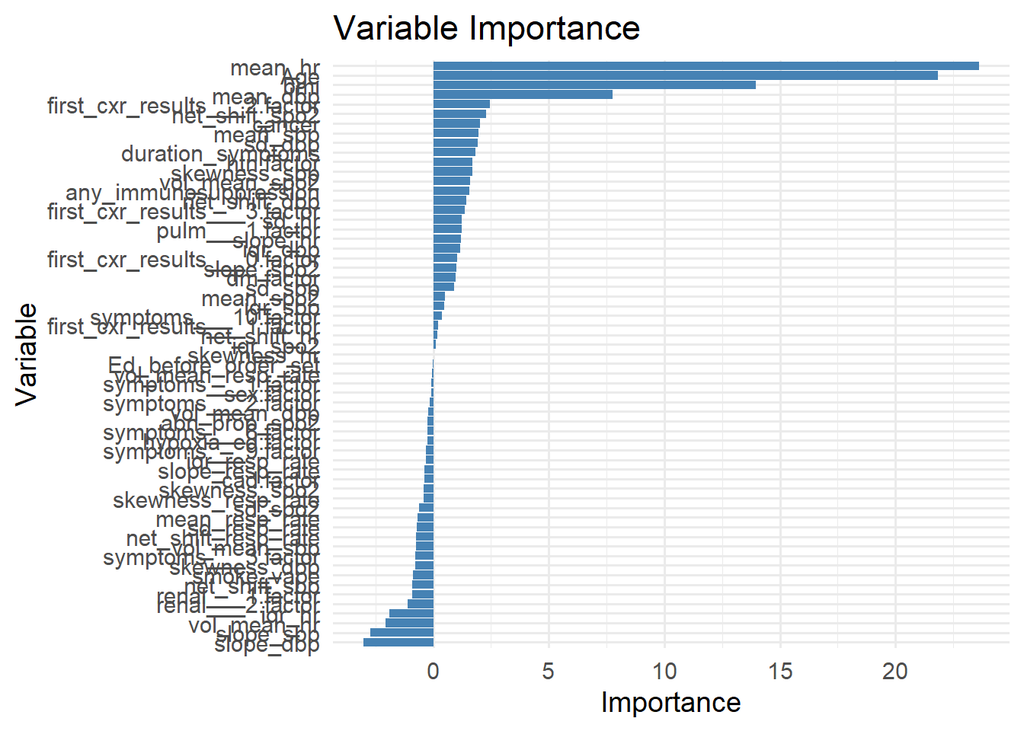

```r
library(ggplot2)
library(dplyr)

imp <- data.frame(
  Variable = rownames(importance(rf_bag)),
  Importance = importance(rf_bag)[, 1]  # or choose %IncMSE / IncNodePurity
) %>%
  arrange(Importance)

ggplot(imp, aes(x = reorder(Variable, Importance), y = Importance)) +
  geom_col(fill = "steelblue") +
  coord_flip() +
  labs(title = "Variable Importance", x = "Variable", y = "Importance") +
  theme_minimal(base_size = 14)
```

## Support Vector Machine

```r
out <- svm(event~., data = train_data, kernel = 'linear', cost = 10)
summary(out)
```

```
##
## Call:
## svm(formula = event ~ ., data = train_data, kernel = "linear", cost = 10)
##
##
## Parameters:
##    SVM-Type:  C-classification
##  SVM-Kernel:  linear
##        cost:  10
##
## Number of Support Vectors:  359
##
##  ( 179 180 )
##
##
## Number of Classes:  2
##
## Levels:
##  No Yes
```

```r
table(pred = predict(out, test_data), truth = test_data$event)
```

```
##      truth
## pred   No Yes
##   No  163  28
##   Yes  53 160
```

```r
mean(predict(out, test_data) != test_data$event)
```

```
## [1] 0.200495
```

```r
# TODO: Run 10-fold CV
tune.out <- tune(svm, event~., data = train_data, kernel = 'linear', ranges = list(cost=c(0.001, 0.01, 0.1, 1, 5, 10, 100)), tunecontrol = tune.control(cross = 10))

summary(tune.out)
```

```
##
## Parameter tuning of 'svm':
##
## - sampling method: 10-fold cross validation
##
## - best parameters:
##  cost
##  0.01
##
## - best performance: 0.1849608
##
## - Detailed performance results:
##    cost     error dispersion
## 1 1e-03 0.2295969 0.05448488
## 2 1e-02 0.1849608 0.04279204
## 3 1e-01 0.2030459 0.04576891
## 4 1e+00 0.2062486 0.05496841
## 5 5e+00 0.2052072 0.06018639
## 6 1e+01 0.2041545 0.05800238
## 7 1e+02 0.2020157 0.05890206
```

```r
# TODO: Extract and summarize best model
bestmod <- tune.out$best.model
summary(bestmod)
```

```
##
## Call:
## best.tune(METHOD = svm, train.x = event ~ ., data = train_data, ranges = list(cost = c(0.001,
##     0.01, 0.1, 1, 5, 10, 100)), tunecontrol = tune.control(cross = 10),
##     kernel = "linear")
##
##
## Parameters:
##    SVM-Type:  C-classification
##  SVM-Kernel:  linear
##        cost:  0.01
##
## Number of Support Vectors:  576
##
##  ( 290 286 )
##
##
## Number of Classes:  2
##
## Levels:
##  No Yes
```

```r
# TODO: Predict using best model
ypred <- predict(bestmod, test_data)

# TODO: Test confusion table and misclassification rate
table(pred = ypred, truth = test_data$event)
```

```
##      truth
## pred   No Yes
##   No  159  27
##   Yes  57 161
```

```r
mean(ypred != test_data$event)
```

```
## [1] 0.2079208
```